# Trend

© Alexander Doynikov,dep. CS, MSU

October 10, 2018

# Тренд

```r
library("TSA")
```

Понятие тренда имеет довольно субъективный характер. В частности, в процессе случайного блуждания можно сказать, что присутствует тренд

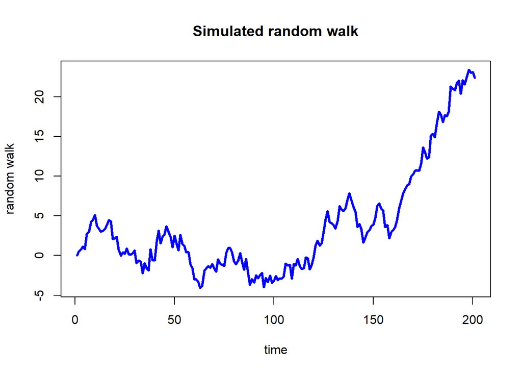

```r
n<-200
e <- rnorm(n)
x <- diffinv(e,lag = 1,differences = 1,0)
matplot(x,type = "l",main= "Simulated random walk",lwd = 3,col = "blue",xlab ="time",ylab = "random walk")
```

Однако известно, что $E[x_t]=0$ для любого $t$. Некоторые авторы их называют такие случайные тренды “стохастическими трендами”.

## Постоянное среднее

Начнем с простейшей модели

$y_t= x_t+\mu: t=i,...,n$

где $E[x_t]=0$ для всех $t$

Чаше всего в качестве оценки $\mu$ используют обычное среднее

$\mu=\widehat{y}= \frac{\sum_{i=1}^n}{n}y_i$

Пусть $y_t$ или что эквиалентно $x_t$ стационарный процесс с автокорреляционной функцией $\rho_k$. Тогда дисперсия оценки $D[\widehat{y_t}]$ равна

$D[\widehat{y_t}]=\frac{c_0}{n}\sum_{k=-n+1}^{n+1}(1-\frac{|k|}{n})\rho_k$

Для нестационарного процесса случайного блуждания $x_t$

$D[\widehat{y_t}]=\frac{1}{n^2}D[\sum_{i=1}^nY_i]=$ $\frac{1}{n^2}D[\sum_{i=1}^n\sum_{j=1}^i\epsilon_j]=$ $\frac{1}{n^2}D[\epsilon_1+2\epsilon_2+3\epsilon_3+...+n\epsilon_n]=$ $\frac{1}{n^2}\sigma_{\epsilon}^2\sum_{k=1}^nk^2=$ $\sigma_{\epsilon}^2(2n+1)\frac{n+1}{6n}$

Для произвольного стационарного процесса с автокорреляционной функцией $\rho_k$ такой, что

$\sum_{k=1}^n|\rho_k|<\infty$

При $n->\infty$ справедливо следующее приближение
$$D[\widehat{y_t}]\approx\frac{c_0}{n}\sum_{k=-\infty}^\infty\rho_k \mspace{40mu}(1)$$

В качестве примера пусть у процесса $x_t$ автокорреляционная функция $\rho_k=\phi^k$ тогда

$D[\widehat{y}_t]\approx\frac{(1+\phi)*c_0}{n(1-\phi)}$

Пример такого процесса

$x_t=\phi x_{t-1}+\epsilon_t$ при $|\phi|<1$

Это процесс называется процессом авторегрессии первого порядка. Сейчас мы его смоделируем непосредственно по определению. Позднее моделировать такие процессы будем одной строчкой кода.

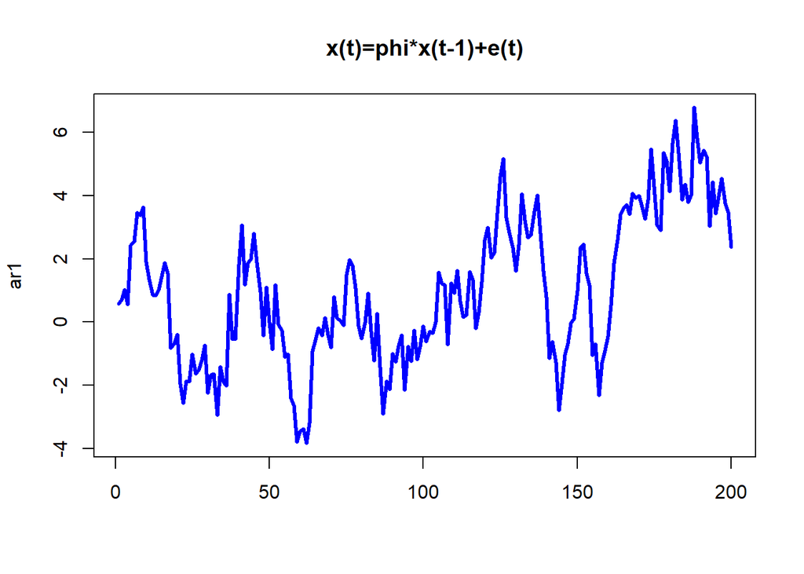

```r
phi <- 0.9
ar1 <- vector()
ar1 <- c(ar1,e[1])
for (i in 2:n)
{
  ar1 <- c(ar1,phi*ar1[i-1]+e[i])
}
matplot(ar1,main = "x(t)=phi*x(t-1)+e(t)", col="blue",type="l",lwd=3)
```

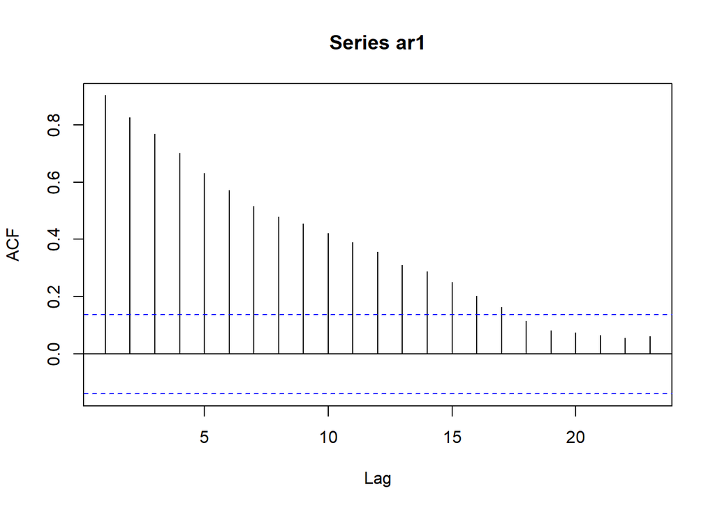

```r
acf(ar1,type= "correlation")
```

## Простая линейная регрессия

Пусть $\mu_t$ неслучайный тренд вида

$\mu_t=\beta_0+\beta_1t: t=1,2,...,n$

Минимизируюя сумму квадратов ошибок

$RSS(\beta_0,\beta_1) = \sum_{t=1}^n(y_t-(\beta_0+\beta_1t))^2$

найдем оценки параметров $\beta_0$ и $\beta_1$. Вычислим частные производный и, приравнивая их нулю, получим

$\frac{\partial RSS(\beta_0,\beta_1)}{\partial{\beta_0}}= 0$

$\frac{\partial RSS(\beta_0,\beta_1)}{\partial{\beta_1}}= 0$

получим

$\widehat{\beta}_1=\frac{\sum_{t=1}^n(y_t-\overline y)(t-\overline t)}{\sum_{t=1}^n(t-\overline t)^2}$

$\beta_0=\overline{y} -\beta_1t$

здесь $\overline{t}=\frac{n+1}{2}$

Пример для случайного блуждания

```r
model1<- lm(x ~time(x))
summary(model1)
```

```
##
## Call:
## lm(formula = x ~ time(x))
##
## Residuals:
##     Min      1Q  Median      3Q     Max
## -7.3927 -4.0794 -0.8401  3.1636 11.7968
##
## Coefficients:
##              Estimate Std. Error t value Pr(>|t|)
## (Intercept) -4.276426   0.710180  -6.022  8.2e-09 ***
## time(x)      0.080158   0.006097  13.147  < 2e-16 ***
## ---
## Signif. codes:  0 '***' 0.001 '**' 0.01 '*' 0.05 '.' 0.1 ' ' 1
##
## Residual standard error: 5.015 on 199 degrees of freedom
## Multiple R-squared:  0.4648, Adjusted R-squared:  0.4621
## F-statistic: 172.8 on 1 and 199 DF,  p-value: < 2.2e-16
```

Позднее в этой лекции дадим описание и назначение всех статистик в этом выводе

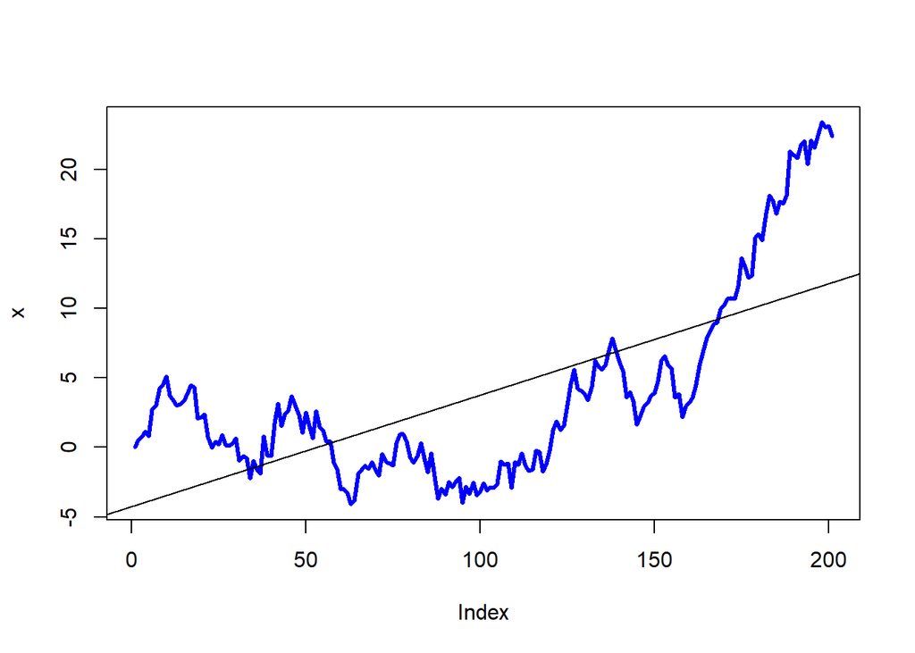

```r
plot(x , col="blue" , type ="l", lwd=3)
abline(model1)
```

## Циклический тренд

Предположим модель будет

$y_t=\mu_t+x_t$

где $E[x_t]=0$,а $\mu_t$ сезонные данные т.е. 12 констант $\beta_1,\beta_2,...,\beta_{12}$ Это модель иногда называют моделью сезонного среднего

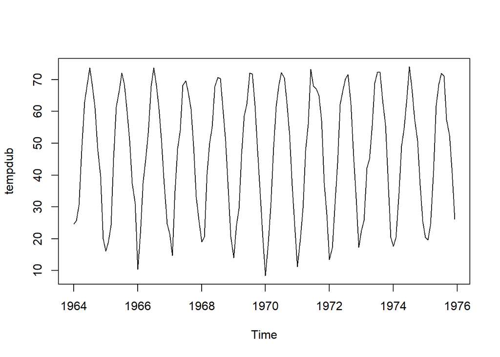

```r
library("TSA")
data(tempdub)
plot(tempdub)
```

Сначала подгоним модель без константы

```r
month.<- season(tempdub)
model2 <- lm(tempdub~month.-1)
summary(model2)
```

```
##
## Call:
## lm(formula = tempdub ~ month. - 1)
##
## Residuals:
##     Min      1Q  Median      3Q     Max
## -8.2750 -2.2479  0.1125  1.8896  9.8250
##
## Coefficients:
##                 Estimate Std. Error t value Pr(>|t|)
## month.January     16.608      0.987   16.83   <2e-16 ***
## month.February    20.650      0.987   20.92   <2e-16 ***
## month.March       32.475      0.987   32.90   <2e-16 ***
## month.April       46.525      0.987   47.14   <2e-16 ***
## month.May         58.092      0.987   58.86   <2e-16 ***
## month.June        67.500      0.987   68.39   <2e-16 ***
## month.July        71.717      0.987   72.66   <2e-16 ***
## month.August      69.333      0.987   70.25   <2e-16 ***
## month.September   61.025      0.987   61.83   <2e-16 ***
## month.October     50.975      0.987   51.65   <2e-16 ***
## month.November    36.650      0.987   37.13   <2e-16 ***
## month.December    23.642      0.987   23.95   <2e-16 ***
## ---
## Signif. codes:  0 '***' 0.001 '**' 0.01 '*' 0.05 '.' 0.1 ' ' 1
##
## Residual standard error: 3.419 on 132 degrees of freedom
## Multiple R-squared:  0.9957, Adjusted R-squared:  0.9953
## F-statistic:  2569 on 12 and 132 DF,  p-value: < 2.2e-16
```

Посмотрим как изменится модель если включить оценку константы

```r
month.<- season(tempdub)
model3 <- lm(tempdub~month.)
summary(model3)
```

```
##
## Call:
## lm(formula = tempdub ~ month.)
##
## Residuals:
##     Min      1Q  Median      3Q     Max
## -8.2750 -2.2479  0.1125  1.8896  9.8250
##
## Coefficients:
##                 Estimate Std. Error t value Pr(>|t|)
## (Intercept)       16.608      0.987  16.828  < 2e-16 ***
## month.February     4.042      1.396   2.896  0.00443 **
## month.March       15.867      1.396  11.368  < 2e-16 ***
## month.April       29.917      1.396  21.434  < 2e-16 ***
## month.May         41.483      1.396  29.721  < 2e-16 ***
## month.June        50.892      1.396  36.461  < 2e-16 ***
## month.July        55.108      1.396  39.482  < 2e-16 ***
## month.August      52.725      1.396  37.775  < 2e-16 ***
## month.September   44.417      1.396  31.822  < 2e-16 ***
## month.October     34.367      1.396  24.622  < 2e-16 ***
## month.November    20.042      1.396  14.359  < 2e-16 ***
## month.December     7.033      1.396   5.039 1.51e-06 ***
## ---
## Signif. codes:  0 '***' 0.001 '**' 0.01 '*' 0.05 '.' 0.1 ' ' 1
##
## Residual standard error: 3.419 on 132 degrees of freedom
## Multiple R-squared:  0.9712, Adjusted R-squared:  0.9688
## F-statistic: 405.1 on 11 and 132 DF,  p-value: < 2.2e-16
```

Обратим внимание, что январь пропущен. И февраль интерпертируется как разность между январем и февралем, март - разность между мартом и январем и т.д.

## Косинусоидальный тренд

Пусть модель

$\mu_t=\beta cos(2\pi ft+\Phi)$

здесь $\beta$ - амплитуда, а $f$ - частота, естественно $1/f$ период. Наблюдения повторяются через каждые $1/f$ момента времени. В модель параметры $\beta$ и $\Phi$ входят нелинейно, но после преобразования

$\beta cos(2\pi ft+\Phi)= \beta_1cos(2\pi ft)+\beta_2sin(2\pi ft)$

где $\beta=\sqrt{\beta_1^2+\beta_2^2}$ $\Phi= atan(-\beta_2/\beta_1)$ Уже можно проводить линейную регрессию просто $cos(2\pi ft),sin(2\pi ft)$ играют роль известных предикторов Подгоним модель тренда

$\mu_t =\beta_0+\beta_1 cos (2\pi ft) +\beta_2 sin(2\pi ft)$

к данным по температуре

```r
har.<-harmonic(tempdub,1)
model4<-lm(tempdub~har.)
summary(model4)
```

```
##
## Call:
## lm(formula = tempdub ~ har.)
##
## Residuals:
##      Min       1Q   Median       3Q      Max
## -11.1580  -2.2756  -0.1457   2.3754  11.2671
##
## Coefficients:
##                 Estimate Std. Error t value Pr(>|t|)
## (Intercept)      46.2660     0.3088 149.816  < 2e-16 ***
## har.cos(2*pi*t) -26.7079     0.4367 -61.154  < 2e-16 ***
## har.sin(2*pi*t)  -2.1697     0.4367  -4.968 1.93e-06 ***
## ---
## Signif. codes:  0 '***' 0.001 '**' 0.01 '*' 0.05 '.' 0.1 ' ' 1
##
## Residual standard error: 3.706 on 141 degrees of freedom
## Multiple R-squared:  0.9639, Adjusted R-squared:  0.9634
## F-statistic:  1882 on 2 and 141 DF,  p-value: < 2.2e-16
```

Здесь $t$ измеряется в годах и частота наблюдений 1 год. На графике косинусоидальная модель и данные по температуре выглядят следующим образом

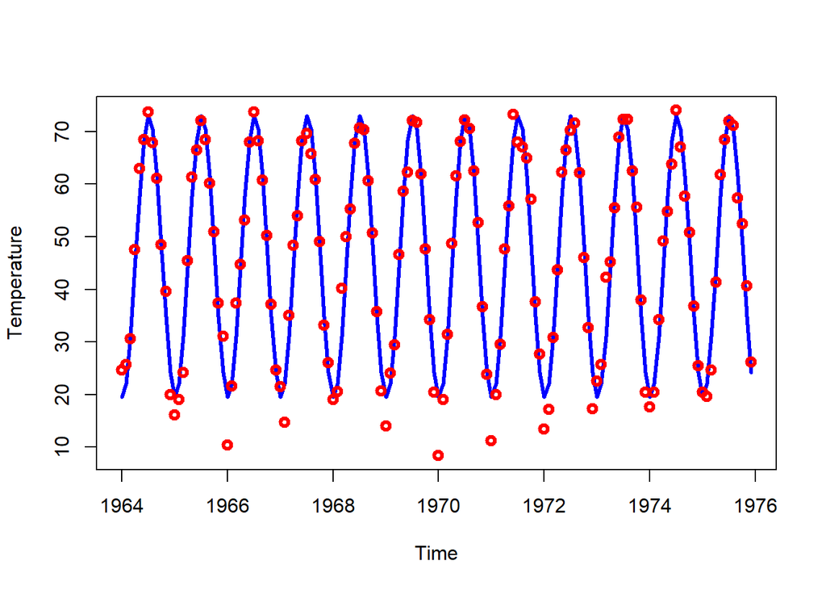

```r
 plot(ts(fitted(model4),freq=12,start=c(1964,1)),
ylab="Temperature",type='l',col = "blue",lwd = 3,
ylim=range(c(fitted(model4),tempdub)))
points(tempdub,col="red",lwd=3)
```

## Оценка дисперсии регрессионных оценок

Итак мы рассмотрели модель линейной регрессии вида

$y_t=\mu_t+x_t$

где стационарный процесс $x_t$ имеет $E[x_t]=0$,а $\mu_t$ детерминированный тренд одного из рассмотренных выше типов: линейный, сезонный, косинусоидальный.

Начнем с простейшей сезонной модели. Оценки параметров $\beta_1,\beta_2,...,\beta_{12}$ по сути есть средние за все январи, феврали,…, декабри. Если количество полных годов мы обозначим за $N$ то среднее за каждый $j$-ый месяц года $j = 1,..,12$ и есть оценка $\widehat{\beta}_j$

$\widehat{\beta}_j=\frac{1}{N}\sum_{i=0}^{N-1}y_{j+12i}$

Чтобы вычислить дисперсию оценки вспомним выражение (1). Заменяя в нем $n$ на $N$, а $\rho_k$ на $\rho_{12}$ получим

$D[\widehat{\beta}_j]= \frac{c_0}{N}[1+2\sum_{k=1}^{N-1}(1-\frac{k}{N})\rho_{12}]$ для $j=1,..,12$

Если предположить, что $x_t$- белый шум, а следовательно все $\rho_k=0$ то выражение выше сократится до

$D[\widehat{\beta}_j]= \frac{c_0}{N}$ для $j=1,..,12$

Более того оно останется таким же, если несколько $\rho_k\ne0$ , но $\rho_{12}=0$

Теперь посмотрим косинусоидальный тренд

Оценки параметров $\beta_1$ и $\beta_2$ амплитуд косинуса и синуса для всех частот вида $m/n$ где $m=1,2,...,n/2-1$

$\widehat{\beta}_1=\frac{2}{n}\sum_{t=1}^{n}\frac{cos(2\pi mt)}{n}y_t$ , $\widehat{\beta}_2=\frac{2}{n}\sum_{t=1}^{n}\frac{sin(2\pi mt)}{n}y_t$

Поскольку $y_t$ в оценки входит линейно

$D[\widehat{\beta}_1]=\frac{2c_0}{n}[1+\frac{4}{n}\sum_{s=2}^n\sum_{t=1}^{s-1}cos(\frac{2\pi mt}{n})cos(\frac{2\pi ms}{n})\rho_{s-t}]$

где мы использовали факт,что $\sum_{t=1}^n[cos(2\pi mt/n)]^2=n/2$

Если $x_t$- белый шум, то все $\rho_k=0$ и опять выражение для дисперсии сократится до $D[\widehat{\beta}_j]= \frac{c_0}{N}$ Теперь рассмотрим модель с линейным трендом

$\mu_t=\beta_0+\beta_1t: t=1,2,...,n$

С оценкой параметра $\beta_1$

$\widehat{\beta}_1=\frac{\sum_{t=1}^n(y_t-\overline y)(t-\overline t)}{\sum_{t=1}^n(t-\overline t)^2}$

Здесь также оценка есть линейная комбинация $y_t$, поэтому

$D[\widehat{\beta}_1]=\frac{12c_0}{n(n^2-1)}[1+\frac{24}{n(n^2-1)}\sum_{s=2}^n\sum_{t=1}^{s-1}(t-t\overline)(s-t\overline)\rho_{s-t}]$

Здесь использован тот факт, что $\sum_{t=1}^n (t-t\overline )=\frac{n(n^2-1)}{12}$

## Интерперетация статистик вывода

Мы производили оценку регрессионных моделей при минимальных предположениях относительно шума $x_t$. Однако вывод стандартных методов регресиионного анализа зависит от дополнительных предположений относительно распределения процесса $x_t$. Стандартным предположением здесь является то, что $x_t$ имеет нормальное распределение. Рассмотрим вывод результатов оценки параметров линейной регрессии для случайного блуждания

```r
model1<- lm(x ~time(x))
summary(model1)
```

```
##
## Call:
## lm(formula = x ~ time(x))
##
## Residuals:
##     Min      1Q  Median      3Q     Max
## -7.3927 -4.0794 -0.8401  3.1636 11.7968
##
## Coefficients:
##              Estimate Std. Error t value Pr(>|t|)
## (Intercept) -4.276426   0.710180  -6.022  8.2e-09 ***
## time(x)      0.080158   0.006097  13.147  < 2e-16 ***
## ---
## Signif. codes:  0 '***' 0.001 '**' 0.01 '*' 0.05 '.' 0.1 ' ' 1
##
## Residual standard error: 5.015 on 199 degrees of freedom
## Multiple R-squared:  0.4648, Adjusted R-squared:  0.4621
## F-statistic: 172.8 on 1 and 199 DF,  p-value: < 2.2e-16
```

Процесс $x_t$ имеет постоянную дисперсию. Оценивая дисперсию остатков, мы оцениваем дисперсию $x_t$.

$s^2 = \frac{1}{n-p}\sum_{t=1}^n(y_t-\widehat{\mu}_t)^2$

здесь $p$ количество оцениваемых параметров и $n-p$ так называемое число степеней свободы для оценки стандартного отклонения $s=\sqrt(s^2$). Величина $s$ постейшая мера качества оценки модели. Чем $s$ меньше, тем лучше качество оценки. Другой мерой качества оценки есть величина $R^2$ также называемая коэффициентом детерминации. Величина $R^2$ интерпретируется как квадрат выборочной rкорреляции между наблюдаемыми данными $y_t$ и оцененным трендом $\widehat{\mu}_t$. Выраженный в процентах $R^2 100$% - сколько процентов изменчивости в наблюдениях объясняет подогнанный линейный тренд. Этот показатель очень удобен при сравнении моделей с разным числом параметров. Следует выбрать ту модель, где показатель $R^2$ больше. Adjusted R-Squared интерпретируется также, но вычисляется по чуть измененной формуле. Стандартные отклонения оценок параметров помечены меткой Std.Error. С интерпретацией этих параметров следует быть аккуратным. Величины t-values это оценнный параметр модели, поделенный на его стандартное отклонение. В слечае нормальное распределенности $x_t$ эти величины имеют$t$-распределение Стьюдента и используются для проверки нулевой гипотезы о том, что соответствующий параметр равен 0, а следовательно напрасно включен в модель. Подстановка значений t-values в фукцию t-распределения Стьюдента дает p-значения p-values. Что позволяет сделать выбор между отклонением или не отклонением нулевой гипотезы обоснованным для выбранного уровня значимости  
F-statistics - статистика для проверки гипотезы об отсутствии связи между $y_t$ и $\mu_t+x_t$ при конкретном задании модели тренда $\mu_t$. За ней следуют число степеней свободы F распределения вероятностей и Р-значение для проверки указанной выше гипотезы

## Множественная линейная регрессия

Предположим, что _t представимо в виде

$\mu_t=\beta_0+\beta_1 x_{t,1}+...\beta_{p}x_{t,p}$

Где $x_{t,k},k=1,...,p$ - известные постоянные. Обычно в качестве таких переменных берут величины , которые находятся под контролем экспериментатора и измеряются с пренебрежимо малой ошибкой, а $\beta_0,\beta_1,...,\beta_{p}$ - неизвестные параметры, подлежащие оценке. Пусть значения $x_{t,k}$ изменяются и исследователю доступны $n$ их различных наборов и при этом наблюдается $n$ значений $Y_1₁,Y_2,...,Y_{n}$ переменной $Y$, тогда

$Y_{t}=\beta+\beta x_{t,1}+...\beta_{p}x_{t,p-1}+\epsilon_{t}, t=1,...,n$

Или в матричной форме

$Y=X\beta+\epsilon$

Здесь мы предположили, что $x_{t,0}=1, i=1,...n$

Maтрица $X$ размера $(n \times p+1)$ называется регрессионной матрицей. Переменные $x_{t,k},k=1,...,p$ обычно называют независимыми переменными, регрессорами или предикторами, а переменнуя $Y_t$ называют зависимой переменной или откликом.

Пример 1. Пусть $x_{t,k}=t^{k}$. Получаем полиномиальную модель

$Y_{t}=\beta_0+\beta_1 t+...\beta_{p}t^{p}+\epsilon_{t}, t=1,...n.$

Пример 2. Пусть $t$- интерпретируется как время и принимает значания $1, 2, ...n.$ $x_{t,k}=x_{t-k}$ лаговая переменная, т.е. перееменная с временной задержкой в к единиц времени, тогда

$Y_{t}=\beta_0+\beta_1x_{t-1}+...\beta_{p}x_{p}+\epsilon_t, t=1,.n$

Последнюю модель называют моделью авторегрессии порядка $p$. Общим в этих примерах является то, что они линейны по отношению к неизвестным параметрам $\beta_0,\beta_1,...,\beta_{p}$ Поэтому модель называют $линейной$ регрессионной моделью. Наиболее популярным методом получения оценок параметров $\beta_0,\beta_1,...,\beta_{p}$. является так называемый метод наименьших квадратов. Метод заключается в минимизации суммы квадратов ошибок $\epsilon′\epsilon=\sum_{i}\epsilon_{i}^2$ относительно вектора параметров $\beta=[\beta_0,\beta_1₁,...,\beta_p]$

Представим $\epsilon′\epsilon$ в виде

$\epsilon′\epsilon=(Y-X\beta)′(Y-X\beta)=Y′Y-2\beta′X′Y+\beta′X′X\beta$

Продифференцируем $\epsilon′\epsilon$ по $\beta$. Пpиравняем полученную производную нулю получим

$-2X′Y+2X′X\beta=0$

или

$X′X\beta=X′Y$

Последние уравнения называют нормальными уравнениями. Решение этого уравнения вектор $\tilde\beta$ называют оценкой наименьших квадратов. Простой проверкой нетрудно убедиться, что $\tilde\beta$ доставляет минимум для $\epsilon′\epsilon.\epsilon′\epsilon$ обозначают как RSS. Вектор $\widetilde{Y}=X\tilde\beta=\tilde\beta_0+\tilde\beta_1x_{t,1}+...\tilde\beta_{p}x_{t,p}$ называют регрессией, а вектор $e=Y-\widetilde Y$ называют остатками.

```
$e=Y-\widetilde{Y}=Y-X\tilde\beta$
```

Отметим, что при известных из линейной алгебры условиях на матрицу $X′X$ оценки $\tilde\beta$ и ошибки $e$ будут единственны.

### Свойства оценок наименьших квадратов

1. Предположим, что вектор ошибок имеем нулевое математическое ожидание $E[\epsilon]=0$. Тогда $E[\tilde\beta]=(X′X)^{-1}X′E[Y]=(X′X)^{-1}X′X\beta=\beta$

Таким образом $\tilde\beta$ являются несмещеными оценками вектора $\beta$.

2. Предположим, что все $\epsilon_{i} i=1,...,n$ некоррелированы и имеют одинаковую дисперсию, т.е. $D[\epsilon]=\sigma^2I_{n}$ тогда

$D[Y]=D[Y-X\tilde\beta]=D[\epsilon]=\sigma^2I_{n}$

И

$D[\tilde\beta]=D[(X′X)^{-1}X′Y]=(X′X)^{-1}X′D[Y]X(X′X)^{-1}=\sigma^2(X′X)^{-1}X′X(X′X)^{-1}=\sigma^2(X′X)^{-1}$

Возникает вопрос почему именно $\tilde\beta$ наиболее популярна при оценке параметров в линейной регрессионной модели. Ответ на этот вопрос дает следующая теорема

$Теорема.$

Пусть $θ$ - оценка наименьших квадратов вектора $θ=X \tilde\beta$. Тогда в классе всех других линейных несмещенных оценок линейной комбинации $c′θ$, оценка $c'θ$ является единственной оценкой с минимальной дисперсией.

До сих пор мы не делали никаких предположений о распределении. Если предоположить независимость и нормальность распределения ошибок $\epsilon_t\sim N(0,\sigma^2)$ то Rao в 1974 году доказал, что $c′\tilde\beta$ имеет минимальную дисперсию не только в классе всех линейных несмещенных оценок, но и в классе всех несмещенных оценок (эффективность). В этом случае также оценка максимального правдоподобия совпадает с оценкой наименьших квадратов. В случае не нормальности рапределения ошибок условия при которых оценка наименьших будет является ассимпототически эффективной найдены были Cox в 1968 году.

Дополнительно будем предполагать нормальность и независимость ошибок $\epsilon_{i} \sim N(0,\sigma^2) или \epsilon∼N(0,I_{n}\sigma^2)$

Теорема 2.Если $Y\sim N(X\beta,I_{n}\sigma^2)$ и матрица $X$ размера $(n⊗p)$ имеет ранг $p$, тогда

1. $\tilde\beta \sim N(\beta,\sigma^2(X′X)^{-1})$
2. $(\tilde\beta-\beta)′X(\tilde \beta-\beta)/\sigma^2\sim\chi^2_p$
3. $\tilde\beta$ не зависит от $s^2$ как случайные величины
4. $RSS/\sigma^2=(n-p)s^2/\sigma^2∼\chi_{n-p}²$

Пример. Полиномиальная регрессия.

Готовим предиктор

```r
q <- seq(from=0, to=20, by=0.1)
```

Вычисляем значения полинома.

```r
y <- 500 + 0.4 * (q-10)^3
```

Генерируем нормальный шум, добавляем его к полиному и рисуем.

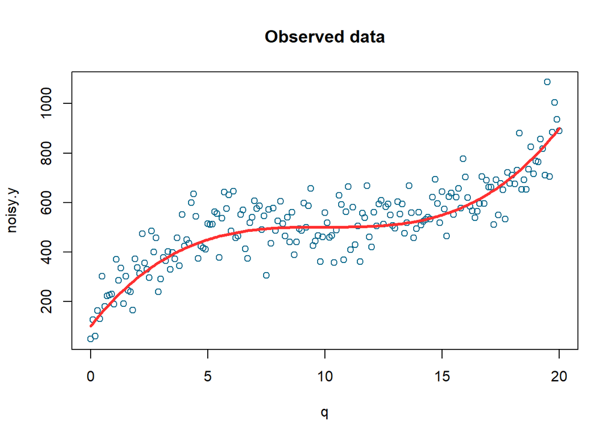

```r
noise <- rnorm(length(q), mean=10, sd=80)
noisy.y <- y + noise
plot(q,noisy.y,col='deepskyblue4',xlab='q',main='Observed data')
lines(q,y,col='firebrick1',lwd=3)
```

Производим оценку модели и смотрим результаты

```r
model <- lm(noisy.y ~ poly(q,3))
summary(model)
```

```
##
## Call:
## lm(formula = noisy.y ~ poly(q, 3))
##
## Residuals:
##      Min       1Q   Median       3Q      Max
## -215.375  -50.663   -5.293   52.602  244.453
##
## Coefficients:
##             Estimate Std. Error t value Pr(>|t|)
## (Intercept)  518.286      5.565  93.127   <2e-16 ***
## poly(q, 3)1 1870.217     78.903  23.703   <2e-16 ***
## poly(q, 3)2  -50.926     78.903  -0.645    0.519
## poly(q, 3)3  887.166     78.903  11.244   <2e-16 ***
## ---
## Signif. codes:  0 '***' 0.001 '**' 0.01 '*' 0.05 '.' 0.1 ' ' 1
##
## Residual standard error: 78.9 on 197 degrees of freedom
## Multiple R-squared:  0.7776, Adjusted R-squared:  0.7742
## F-statistic: 229.6 on 3 and 197 DF,  p-value: < 2.2e-16
```

Доверительные интервалы для оценок

```r
confint(model, level=0.95)
```

```
##                 2.5 %    97.5 %
## (Intercept)  507.3106  529.2613
## poly(q, 3)1 1714.6143 2025.8190
## poly(q, 3)2 -206.5280  104.6767
## poly(q, 3)3  731.5636 1042.7683
```

#### Фрейм визуализации полиномиальной регрессии.

http://pc586s.cs.msu.ru:3838/Doynikov/regression/Polynomial/

#### Пример. Множественная линейная регрессия

Загрузите ряд Ruble.csv на свой компьютер http://pc586s.cs.msu.ru:3838/Doynikov/Time_Series_Analysis/Ruble.csv

Cчитываем временные ряды.

```r
Data<-read.csv("./Ruble.csv",header = TRUE)
head(Data)
```

```
##          X318x6 Rub.Usd brent  sp500 GAZPROM   Gold EUR.USD
## 1 1/11/16 11:00 75.9331 32.97 1915.6   13523 1105.9 1.09005
## 2 1/11/16 12:00 75.5411 33.29 1928.5   13547 1100.0 1.08833
## 3 1/11/16 13:00 75.3761 33.47 1921.6   13507 1099.2 1.08847
## 4 1/11/16 14:00 75.4561 33.20 1916.4   13451 1103.6 1.09006
## 5 1/11/16 15:00 75.3684 33.26 1921.0   13422 1102.6 1.08987
## 6 1/11/16 16:00 75.2620 33.25 1918.0   13436 1103.2 1.08983
```

Оцениваем модель c константой
$$y_t=\beta_0+\beta_1 x_{t,1}+....+\beta_p x_{t,p}+\epsilon_t$$

```r
regr <-  lm(Data$Rub.Usd ~ Data$brent + Data$sp500 + Data$GAZPROM+Data$Gold+Data$EUR.USD, data=Data)
summary(regr)
```

```
##
## Call:
## lm(formula = Data$Rub.Usd ~ Data$brent + Data$sp500 + Data$GAZPROM +
##     Data$Gold + Data$EUR.USD, data = Data)
##
## Residuals:
##     Min      1Q  Median      3Q     Max
## -2.1042 -0.6984 -0.2149  0.5746  3.9030
##
## Coefficients:
##                Estimate Std. Error t value Pr(>|t|)
## (Intercept)   1.833e+02  1.104e+01  16.611  < 2e-16 ***
## Data$brent   -5.191e-01  5.827e-02  -8.909  < 2e-16 ***
## Data$sp500   -1.151e-02  4.221e-03  -2.727  0.00676 **
## Data$GAZPROM -1.464e-03  4.223e-04  -3.467  0.00060 ***
## Data$Gold     5.427e-02  5.932e-03   9.149  < 2e-16 ***
## Data$EUR.USD -9.880e+01  1.062e+01  -9.300  < 2e-16 ***
## ---
## Signif. codes:  0 '***' 0.001 '**' 0.01 '*' 0.05 '.' 0.1 ' ' 1
##
## Residual standard error: 1.106 on 312 degrees of freedom
##   (291 observations deleted due to missingness)
## Multiple R-squared:  0.6616, Adjusted R-squared:  0.6561
## F-statistic:   122 on 5 and 312 DF,  p-value: < 2.2e-16
```

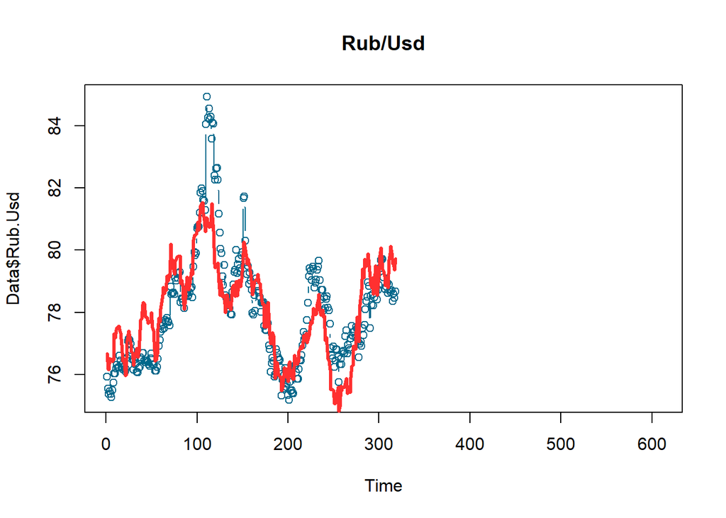

```r
plot(Data$Rub.Usd,type = "b",col='deepskyblue4',xlab='Time',main='Rub/Usd')
lines(regr$fitted.values,col='firebrick1',lwd=3)
```

Остатки после удаления регрессии

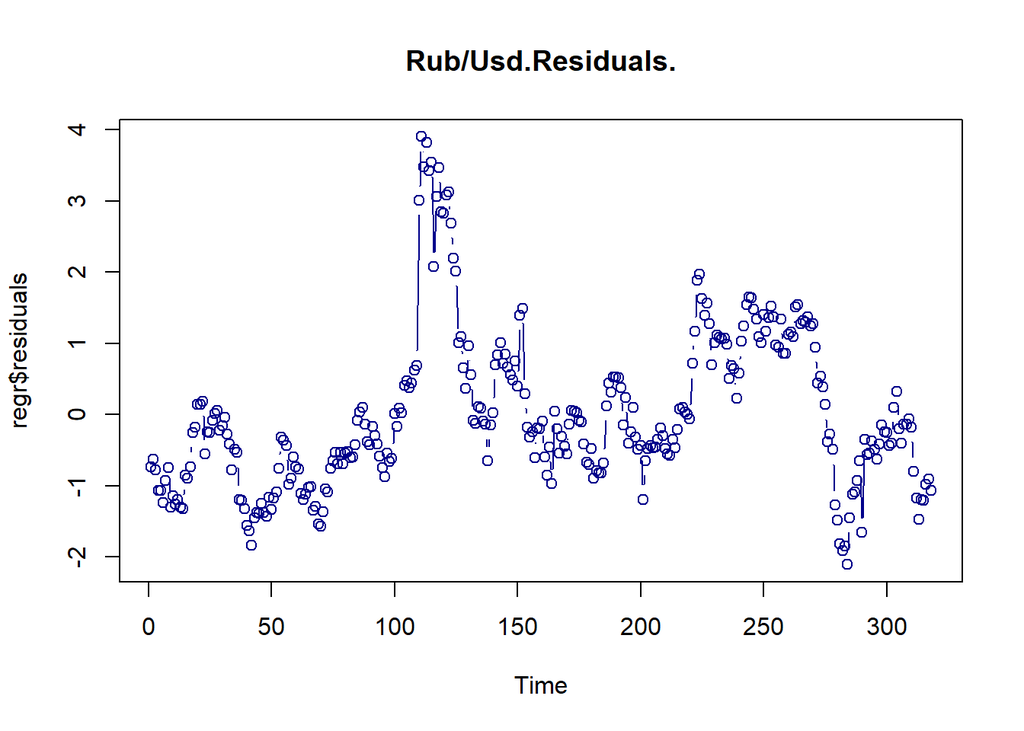

```r
plot(regr$residuals ,type = "b",col='blue4',xlab='Time',main='Rub/Usd.Residuals.')
```

Загрузите ряд RubleRates.csv на свой компьютер http://pc586s.cs.msu.ru:3838/Doynikov/Time_Series_Analysis/RubleRates.csv

Читаем временные ряды доходностей.

```r
DataRates<-read.csv("./RubleRates.csv",header = TRUE)
head(DataRates)
```

```
##          X318x6      Rub.Usd        brent        sp500      GAZPROM
## 1 1/11/16 12:00 -0.005162439  0.009705793  0.006734183  0.001774754
## 2 1/11/16 13:00 -0.002184241  0.005407029 -0.003577910 -0.002952683
## 3 1/11/16 14:00  0.001061344 -0.008066926 -0.002706078 -0.004145998
## 4 1/11/16 15:00 -0.001162265  0.001807229  0.002400334 -0.002155974
## 5 1/11/16 16:00 -0.001411732 -0.000300661 -0.001561687  0.001043064
## 6 1/11/16 17:00  0.003057320  0.001203008  0.003076121  0.000893123
##           Gold       EUR.USD
## 1 -0.005335021 -0.0015779090
## 2 -0.000727273  0.0001286370
## 3  0.004002911  0.0014607660
## 4 -0.000906125 -0.0001743020
## 5  0.000544168 -0.0000367016
## 6 -0.002356780 -0.0015874040
```

Повторим регрессионный анализ для доходностей

```r
regrRates <-  lm(DataRates$Rub.Usd ~ DataRates$brent + DataRates$sp500 + DataRates$GAZPROM+DataRates$Gold+DataRates$EUR.USD, data=DataRates)
summary(regrRates)
```

```
##
## Call:
## lm(formula = DataRates$Rub.Usd ~ DataRates$brent + DataRates$sp500 +
##     DataRates$GAZPROM + DataRates$Gold + DataRates$EUR.USD, data = DataRates)
##
## Residuals:
##       Min        1Q    Median        3Q       Max
## -0.014016 -0.001919 -0.000009  0.001706  0.026740
##
## Coefficients:
##                     Estimate Std. Error t value Pr(>|t|)
## (Intercept)        0.0000792  0.0002117   0.374    0.709
## DataRates$brent   -0.3006449  0.0247424 -12.151  < 2e-16 ***
## DataRates$sp500   -0.3121544  0.0729216  -4.281 2.48e-05 ***
## DataRates$GAZPROM  0.0509342  0.0532328   0.957    0.339
## DataRates$Gold    -0.0660787  0.1003431  -0.659    0.511
## DataRates$EUR.USD -0.0960630  0.1473420  -0.652    0.515
## ---
## Signif. codes:  0 '***' 0.001 '**' 0.01 '*' 0.05 '.' 0.1 ' ' 1
##
## Residual standard error: 0.003747 on 311 degrees of freedom
## Multiple R-squared:  0.5358, Adjusted R-squared:  0.5283
## F-statistic: 71.78 on 5 and 311 DF,  p-value: < 2.2e-16
```

Оцениваем модель без константы и без явно лишних предикторов
$$y_t=\beta_1 x_{t,1}+....+\beta_q x_{t,q}+\epsilon_t$$

```r
regrRates1 <-  lm(DataRates$Rub.Usd ~ DataRates$brent + DataRates$sp500  -1, data=DataRates)
 summary(regrRates1)
```

```
##
## Call:
## lm(formula = DataRates$Rub.Usd ~ DataRates$brent + DataRates$sp500 -
##     1, data = DataRates)
##
## Residuals:
##        Min         1Q     Median         3Q        Max
## -0.0139712 -0.0018486  0.0000472  0.0016979  0.0266948
##
## Coefficients:
##                 Estimate Std. Error t value Pr(>|t|)
## DataRates$brent -0.29528    0.02312 -12.772   <2e-16 ***
## DataRates$sp500 -0.25138    0.05935  -4.235    3e-05 ***
## ---
## Signif. codes:  0 '***' 0.001 '**' 0.01 '*' 0.05 '.' 0.1 ' ' 1
##
## Residual standard error: 0.003738 on 315 degrees of freedom
## Multiple R-squared:  0.5324, Adjusted R-squared:  0.5294
## F-statistic: 179.3 on 2 and 315 DF,  p-value: < 2.2e-16
```

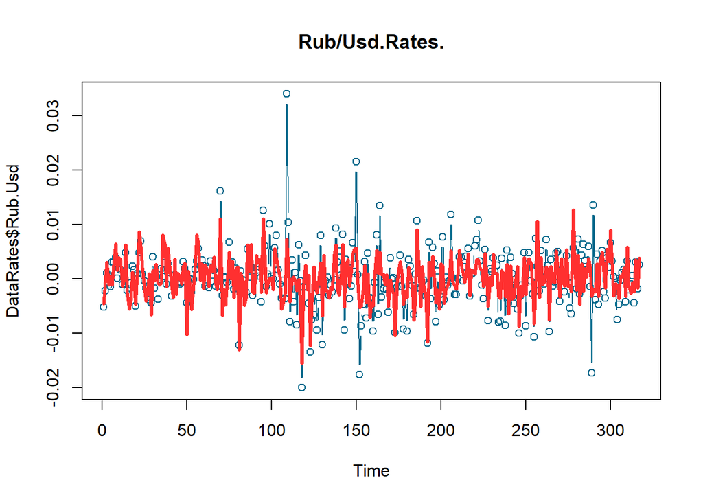

```r
plot(DataRates$Rub.Usd,type = "b",col='deepskyblue4',xlab='Time',main='Rub/Usd.Rates.')
lines(regrRates1$fitted.values,col='firebrick1',lwd=3)
```

Остатки после удаления регрессии

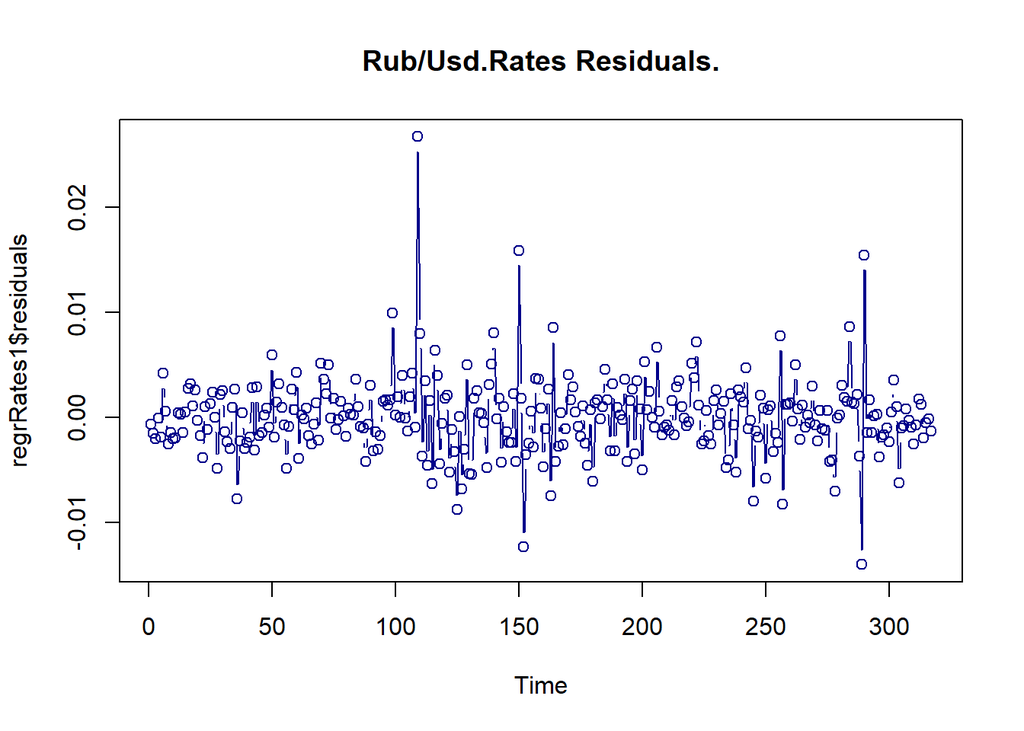

```r
plot(regrRates1$residuals ,type = "b",col='blue4',xlab='Time',main='Rub/Usd.Rates Residuals.')
```

## Анализ остатков

После оценки регрессионной модели можно получить оценку процесса $x_t$, а именно

$\widehat{x}_t=y_t-\widehat{\mu}_t$

которые будем назвать остатками. Если модель тренда была выбрана корректно, то поведение процесса остатков должно быть адекватно предположениям относительно процесса $x_t$ перед оценкой модели. Например если предполагалось,что процесс $x_t$ белый шум, то процесс остатков $\widehat{x}_t$ тоже должен быть белым шумом. Если это не выполняется, это означает, что выбранная модель тренда не учитывает всей специфики динамики ряда. Начнем анализ остатков на примере данных по температуре, к которым оценивалась сезонная модель. Посмотрим на график нормированных остатков после удаления сезонной модели

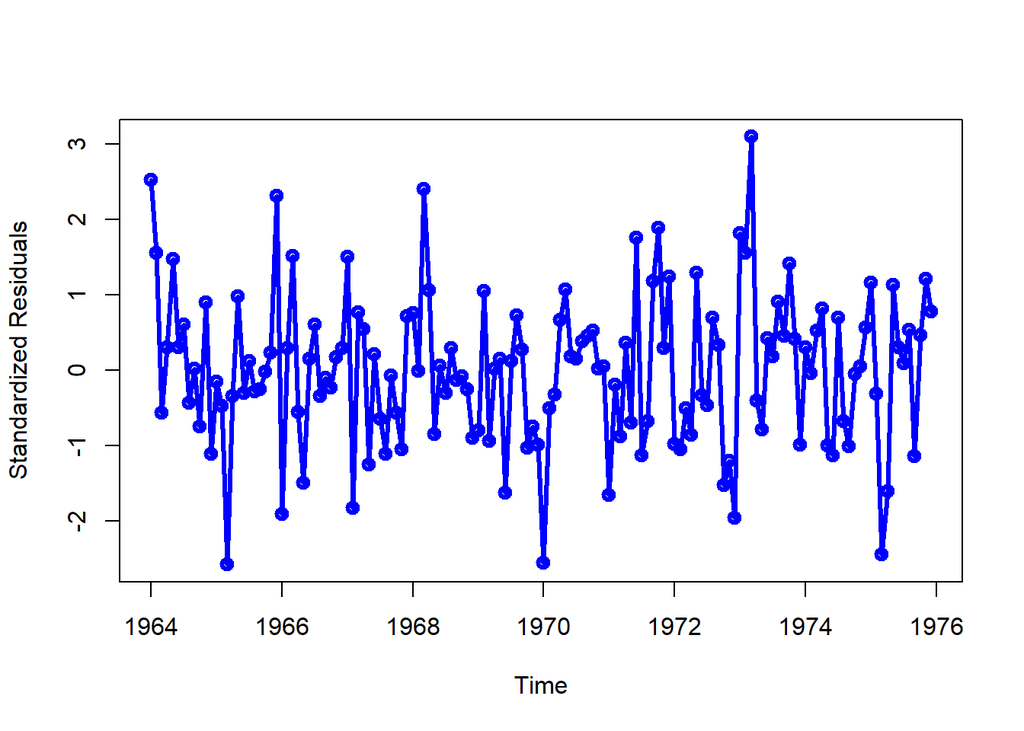

```r
data(tempdub)
plot(y=rstudent(model2),x=as.vector(time(tempdub)),xlab="Time",ylab="Standardized Residuals",type = "o", col = "blue",lwd=3)
```

```r
model2
```

```
##
## Call:
## lm(formula = tempdub ~ month. - 1)
##
## Coefficients:
##   month.January   month.February      month.March      month.April
##           16.61            20.65            32.48            46.53
##       month.May       month.June       month.July     month.August
##           58.09            67.50            71.72            69.33
## month.September    month.October   month.November   month.December
##           61.03            50.98            36.65            23.64
```

Нанесем символы месяцев на график остатков

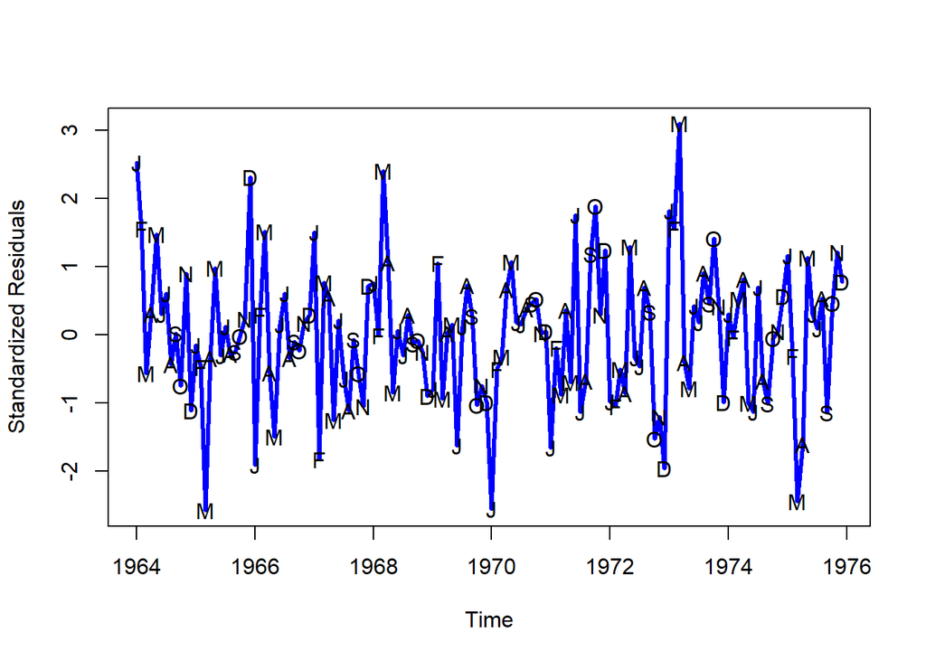

```r
plot(y=rstudent(model2),x=as.vector(time(tempdub)),xlab='Time',
ylab='Standardized Residuals',type='l',col = "blue",lwd = 3)
points(y=rstudent(model2),x=as.vector(time(tempdub)),
pch=as.vector(season(tempdub)))
```

Соберем остатки по месяцам

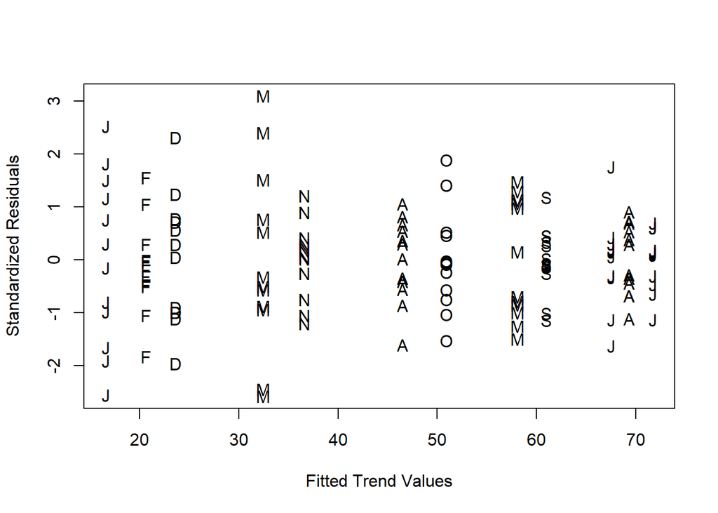

```r
plot(y=rstudent(model2),x=as.vector(fitted(model2)),
xlab="Fitted Trend Values",
 ylab="Standardized Residuals",type = "n")
points(y=rstudent(model3),x=as.vector(fitted(model3)),
pch=as.vector(season(tempdub)))
```

О распределении остатков можно сделать предположения, если посмотреть на гистограмму остатков.

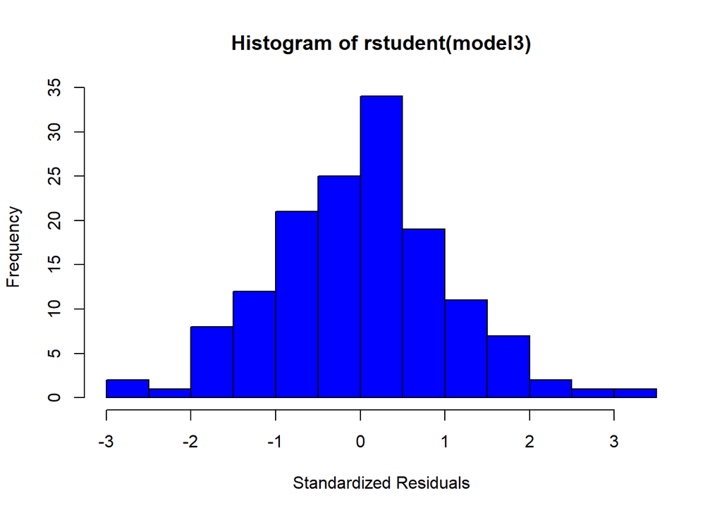

```r
hist(rstudent(model3),xlab='Standardized Residuals', col = "blue")
```

Вид гистограммы наводит на мысль о нормальном распределении остатков. Нормальность остатков может быть проверена различными способами. Начнем с графического, так называемого нормального квантиль-квантиль (QQ) графика. Для нормально распределенных случайных величин QQ график должен выглядеть как прямая. Для остаков сезонной модели QQ график будет таким.

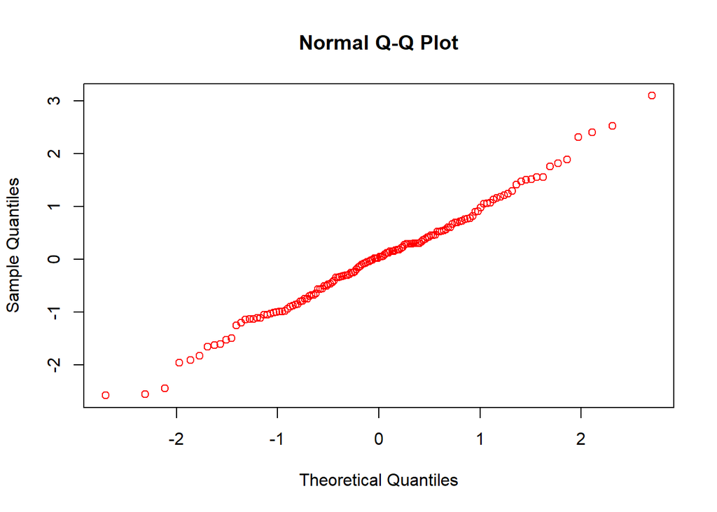

```r
qqnorm(rstudent(model3),col="red")
```

Для примера смоделируем выборку с распределением Стьюдента, с похожей плотностью, и посмотрим на QQ график

О том, как выглядит плотность распределения Стьдента по сравнению с плтоностью нормального распределения напомнит следующий фрейм.

http://pc586s.cs.msu.ru:3838/Doynikov/Distributions/student_distribution/

```r
library("fGarch")
```

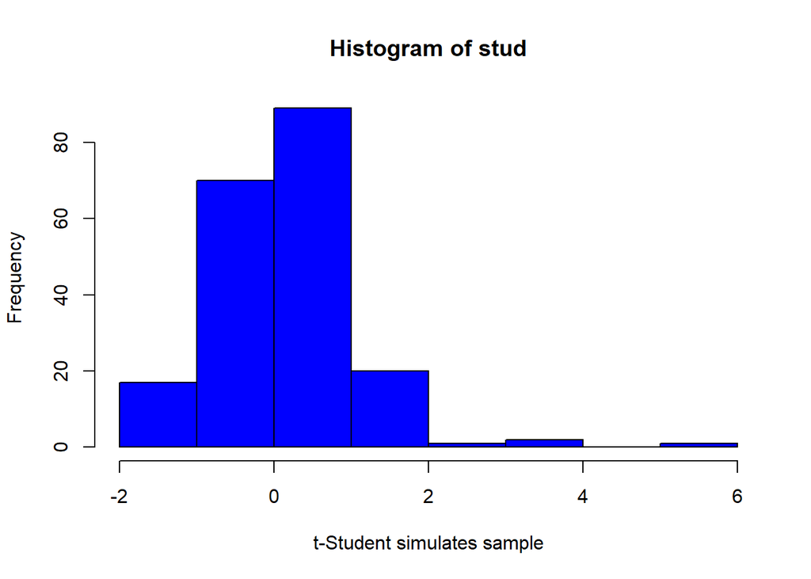

```r
stud<- rstd(200,mean= 0,sd=1,nu=3)
hist(stud,xlab='t-Student simulates sample', col = "blue")
```

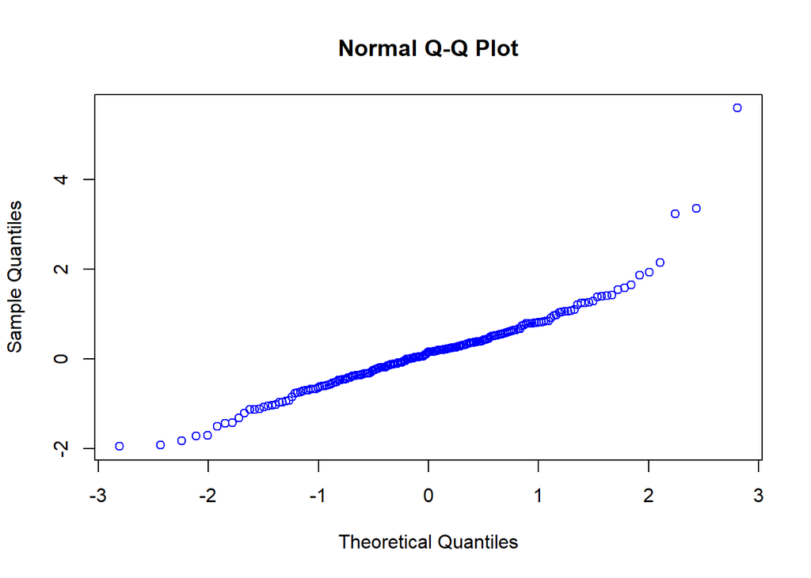

```r
qqnorm(stud,col = "blue")
```

Прекрасный тест на проверку нормальности это тест Шапиро-Вилка (Shapiro-Wilk). О том, как устроен тест можно прочитать, например, здесь htps://en.wikipedia.org/wiki/Shapiro%E2%80%93Wilk_test

```r
 shapiro.test((rstudent(model3)))
```

```
##
##  Shapiro-Wilk normality test
##
## data:  (rstudent(model3))
## W = 0.9929, p-value = 0.6954
```

Для примера проверка на нормальность выборки с распределением Стьюдента

```r
shapiro.test(stud)
```

```
##
##  Shapiro-Wilk normality test
##
## data:  stud
## W = 0.9184, p-value = 4.453e-09
```

Не менее важно проверить не только нормальность (при исходном предположении модели), но и независимость (некооррелируемость) остатков Здесь нам поможет выборочная автокорреляционная функция, введенная в первой лекции

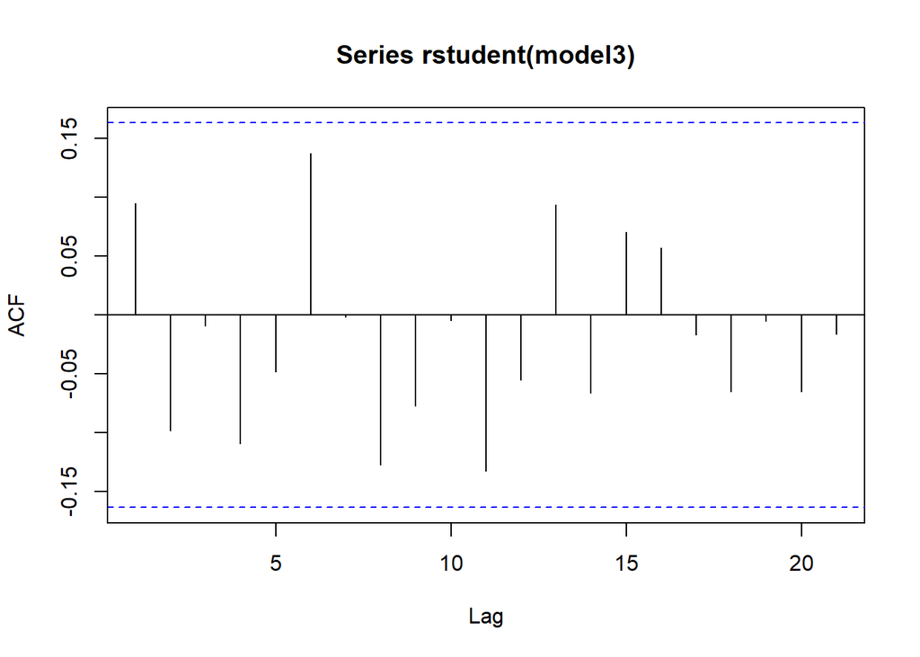

```r
acf(rstudent(model3))
```

Хорошо видно, что все автокорреляции лежат внутри полосы $\pm 2/\sqrt{n}$, что не отвергает гипотезу $\rho_k=0$ для всех $k=\pm1,\pm2,...$

В качестве другого примера анализа остатков рассмотрим случайное блуждание и оценка линии регрессии.

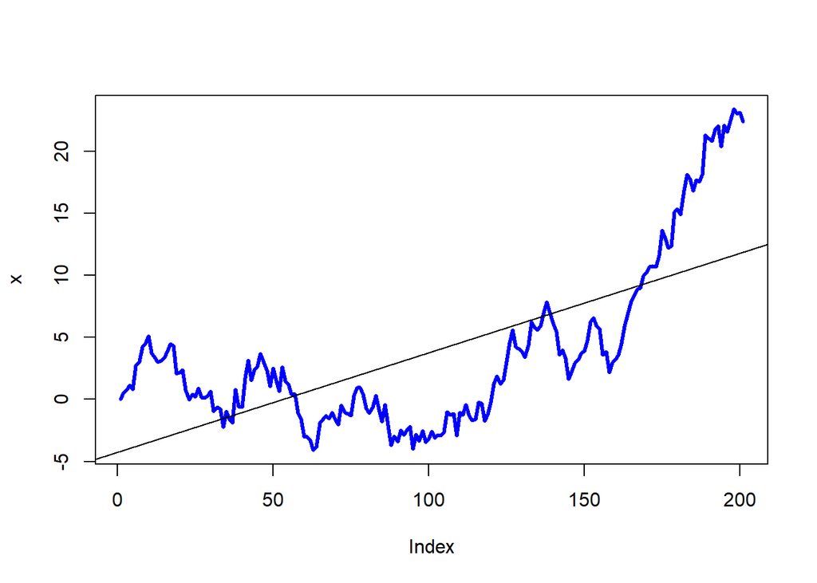

```r
model1<- lm(x ~time(x))
plot(x , col="blue" , type ="l", lwd=3)
abline(model1)
```

Здесь остатки после удаления тренда есть

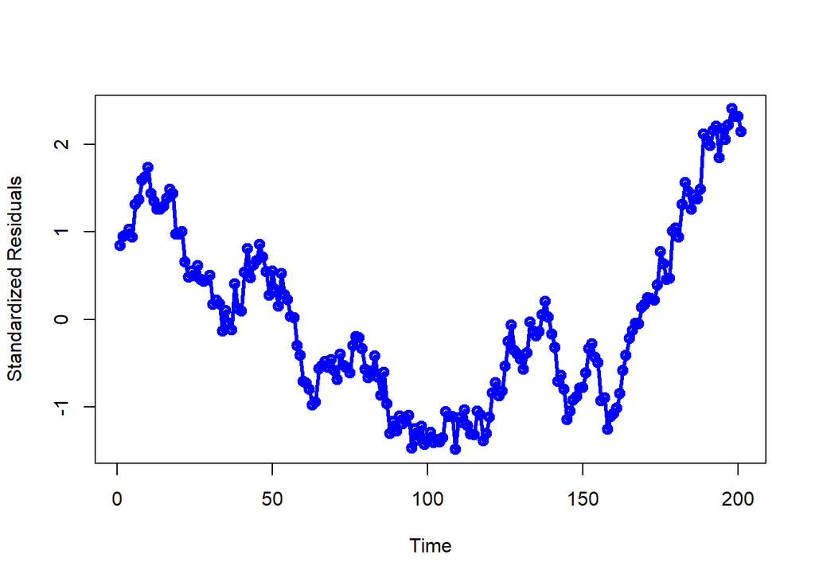

```r
plot(y=rstudent(model1),x=as.vector(time(x)),
ylab="Standardized Residuals",xlab="Time",type="o",col="blue",lwd=3 )
```

ACF остатков после удаления линейного тренда

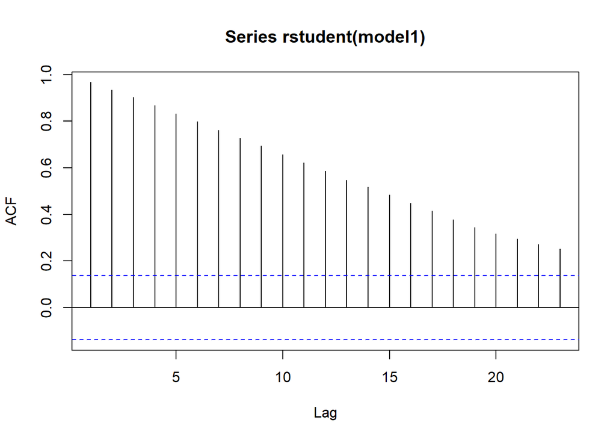

```r
acf(rstudent(model1))
```

ACF остатков заметно выходит за полосу $\pm 2/\sqrt{n}$ таким образом не является белым шумом. Для процессов с такой ACF рассмотрим модели позднее в курсе. Напоследок проверим остатки на нормальность, построив QQ график остатков и выполним тест Шапиро-Вилка

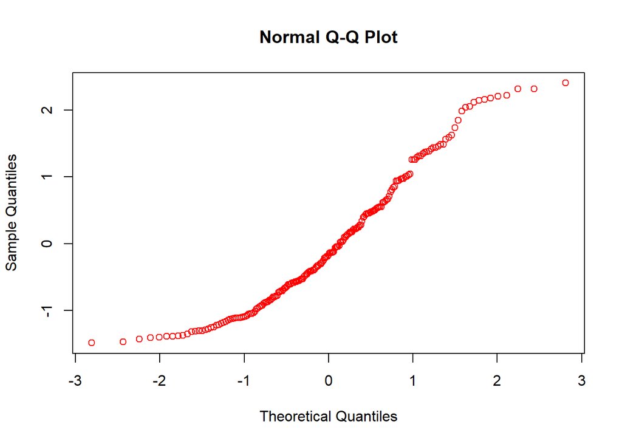

```r
qqnorm(rstudent(model1),col="red")
```

```r
 shapiro.test((rstudent(model1)))
```

```
##
##  Shapiro-Wilk normality test
##
## data:  (rstudent(model1))
## W = 0.94758, p-value = 1.052e-06
```

## Тестовое задание 1

Даны 4 выборки $y_t,x_{t,1},x_{t,2},x_{t,3}$

```r
s <- read.csv("./Test_1_N_Sample.csv",header = TRUE)
head(s)
```

где $N=1,2,3$.

Оценить регрессионную модель
$$y_t=a_0+a_1x_{t,1}+a_2x_{t,2}+a_3x_{t,3}+ \epsilon_t$$
где распределение шума $\epsilon_t$ может быть одним из четырех распределений:

- равномерное на отрезке $[-u,u]$,
- нормальное $N(0,\sigma^2)$,
- Лапласа с параметрами $0,\mu$,
- t-распределение Стьюдента со среднем 0, дисперсией $\sigma^2$ или стандартным отклонием $\sigma$. Именно так задается это распределение в R, а не через более нам привычный параметр - число степеней свободы.

Исключить заведомо незначимые переменные (если такие найдутся), после чего переоценить модель только со значимыми переменными.

Исследовать остатки после удаления модели: определить тип распределения остатков (проверить соответствующие гипотезы и обосновать свой выбор, можно использовать тест Колмогорова-Смирнова,$\chi^2$ Пирсона или любой известный Вам другой), проверить некоррелируемость остатков.

# Литература

- Дрейпер Н. Симт Г. (1986) Прикладной регрессионный анализ М.:Наука
- Себер Дж. (1980) Линейный регрессионный анализ. М.: Мир